# Data605-Week11-HomeWork11-kamath

Vinayak Kamath

11/08/2020

### Home Work 11

Using the “cars” dataset in R, build a linear model for stopping distance as a function of speed and replicate the analysis of your textbook chapter 3 (visualization, quality evaluation of the model, and residual analysis.)

```r
#Displaying the car dataset contents:
str(cars)
```

```
## 'data.frame':    50 obs. of  2 variables:
##  $ speed: num  4 4 7 7 8 9 10 10 10 11 ...
##  $ dist : num  2 10 4 22 16 10 18 26 34 17 ...
```

```r
#Showing stats with Summary function:
summary(cars)
```

```
##      speed           dist
##  Min.   : 4.0   Min.   :  2.00
##  1st Qu.:12.0   1st Qu.: 26.00
##  Median :15.0   Median : 36.00
##  Mean   :15.4   Mean   : 42.98
##  3rd Qu.:19.0   3rd Qu.: 56.00
##  Max.   :25.0   Max.   :120.00
```

**==> First to visualize the `cars` data using scatter plot. The x-axis is speed and y-axis is distance :**

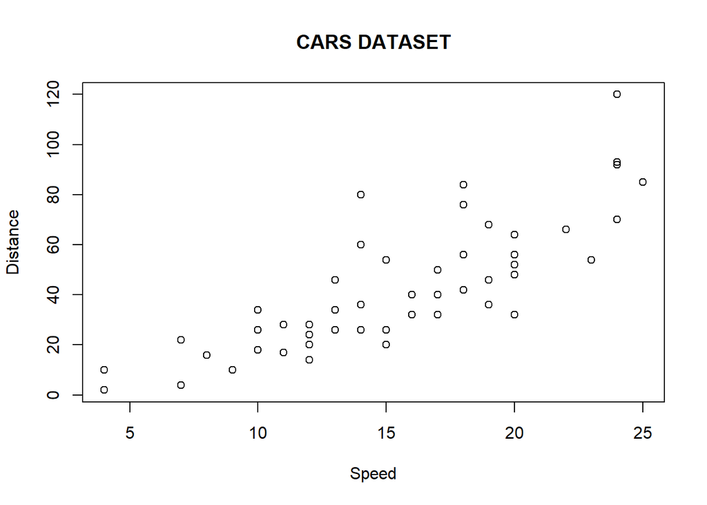

```r
plot(cars[,"speed"], cars[,"dist"], main='CARS DATASET', xlab='Speed', ylab='Distance')
```

*The plot shows that as car speed increases, the stopping distance also inreases as expected. A regression model will help us quantify this relationship.*

**==> Next, The Linear Model Function :**

```r
cars_lm <- lm(cars$dist ~ cars$speed)
cars_lm
```

```
##
## Call:
## lm(formula = cars$dist ~ cars$speed)
##
## Coefficients:
## (Intercept)   cars$speed
##     -17.579        3.932
```

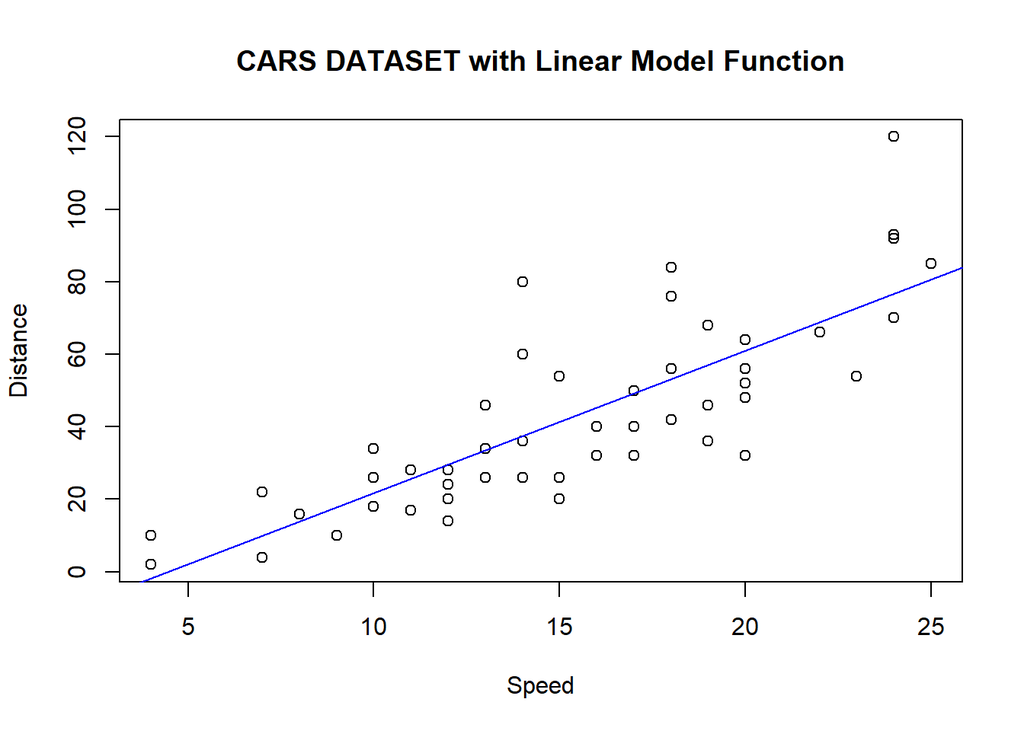

```r
plot(cars[,"speed"], cars[,"dist"], main='CARS DATASET with Linear Model Function', xlab='Speed', ylab='Distance')
abline(cars_lm, col="blue")
```

**==> Next, quality evaluation of the model :**

```r
summary(cars_lm)
```

```
##
## Call:
## lm(formula = cars$dist ~ cars$speed)
##
## Residuals:
##     Min      1Q  Median      3Q     Max
## -29.069  -9.525  -2.272   9.215  43.201
##
## Coefficients:
##             Estimate Std. Error t value Pr(>|t|)
## (Intercept) -17.5791     6.7584  -2.601   0.0123 *
## cars$speed    3.9324     0.4155   9.464 1.49e-12 ***
## ---
## Signif. codes:  0 '***' 0.001 '**' 0.01 '*' 0.05 '.' 0.1 ' ' 1
##
## Residual standard error: 15.38 on 48 degrees of freedom
## Multiple R-squared:  0.6511, Adjusted R-squared:  0.6438
## F-statistic: 89.57 on 1 and 48 DF,  p-value: 1.49e-12
```

*Multiple R-squared value of 0.6511 and Adjusted R-squared of 0.6438 tells us that the model explains about 65% of the data variation. That says that our model is a good fit but may not be an excellent fit for the data provided.*

**==> Next, residual analysis:**

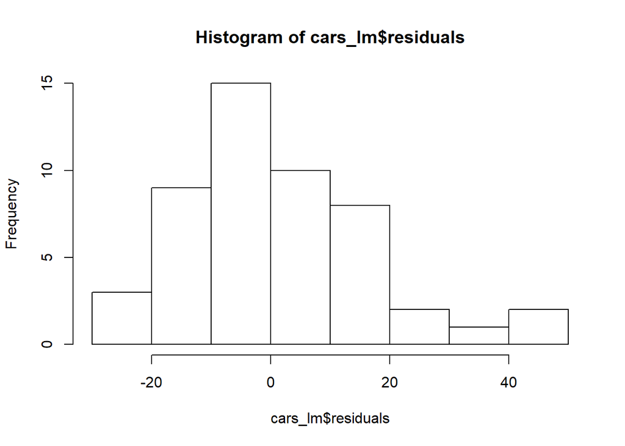

```r
hist(cars_lm$residuals)
```

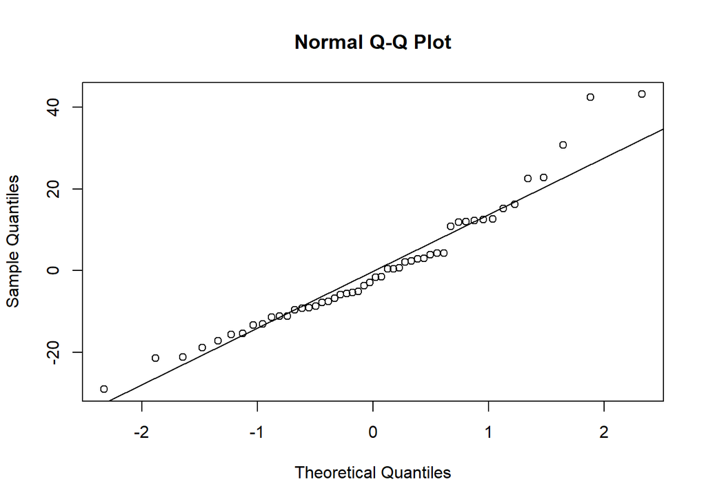

```r
qqnorm(resid(cars_lm))
qqline(resid(cars_lm))
```